# Linear Regression

## Linear Regression

### Regression

Regression analysis is form of predictive modeling technique which investigate the relationship between a dependent variable and independent variable.

**Uses of Regression**  
a. Determining the strength of predtictors  
b. Forecasting an effect  
c. Trend forecasting

#### Types of Regression

1. Linear Regression
2. Logistic Regression
3. Polynomial Regression
4. Stepwise Regression
5. Ridge Regression
6. Lasso Regression
7. ElasticNet Regression

## Linear Regression

Linear Regression is a Supervised Learning Algorithm. Linear Regression model is also know as predictive model. The objective is to train a Linear Regression model on a given data set (labelled data set) and do prediction on new data point. Also see how well the model is predicting and find out the accuracy of the model.

#### In Simple Linear Regression

Model => y = mx + c  
parameters => m and c which our model will learn from the given data set  
Learning type => Supervised Learning  
Model type => Regression Model or predictive model

```python
#import the required libraries
import numpy as np
import matplotlib.pyplot as plt
import pandas as pd
from matplotlib import style

style.use('ggplot')
```

```python
#import the data set
data = pd.read_csv('Salary_Data.csv')
data.head()
```

|  | YearsExperience | Salary |
| --- | --- | --- |
| 0 | 1.1 | 39343.0 |
| 1 | 1.3 | 46205.0 |
| 2 | 1.5 | 37731.0 |
| 3 | 2.0 | 43525.0 |
| 4 | 2.2 | 39891.0 |

Note:

```
YearsExperience is independent variable
Salary is dependent variable (it is the response or label)
```

```python
#store the independent variable in x and response in y
#feature vector
x = data.iloc[:,0]  # or we can use :> data['YearsExperience'].values

#response vector
y = data.iloc[:,1]
```

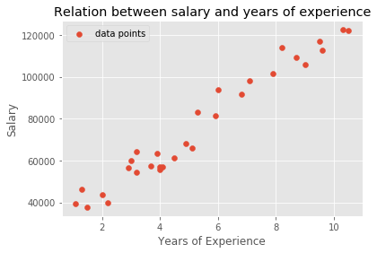

```python
#scatter plot the dataset
plt.xlabel("Years of Experience")
plt.ylabel("Salary")
plt.title("Relation between salary and years of experience")

plt.scatter(x,y,label='data points')
plt.legend()
plt.show()
```

```python
#calculating the parameters of the model i.e. value of m and c
#y = mx + c
#mean of x and y
x_mean = np.mean(x)
y_mean = np.mean(y)

#no of data point
n = len(x)

#using the formula to calculate the m and c value
numerator = 0
denominator = 0

for i in range(n):
    numerator += (x[i] - x_mean)*(y[i] - y_mean)
    denominator += (x[i] - x_mean)**2

m = numerator / denominator
c = y_mean - (m * x_mean)
```

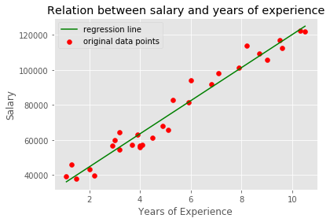

```python
Y = m * x + c

plt.xlabel("Years of Experience")
plt.ylabel("Salary")
plt.title("Relation between salary and years of experience")

plt.scatter(x,y,label='original data points',color='r')
plt.plot(x,Y,label='regression line',color='g')
plt.legend()
plt.show()
```

```python
#predict the value using our model
#Y = m * x + c
Yp = []
for i in range(n):
    Yp.append(m*x[i] + c)
```

### R squared Measure

R-squared is a statistical measure of how close the data are to the fitted regression line. R-squared evaluates the scatter of the data points around the fitted regression line. It is also known as the coefficient of determination, or the coefficient of multiple determination for multiple regression. 100% indicates that the model explains all the variability of the response data around its mean.

R-squared is the percentage of the dependent variable variation that a linear model explains.

R-squared is always between 0 and 100%  
a. 0% represents a model that does not explain any of the variation in the response variable around its mean. The mean of the dependent variable predicts the dependent variable as well as the regression model.  
b. 100% represents a model that explains all of the variation in the response variable around its mean.

```python
R_squared = 1- np.sum(np.square(Yp - y)) / np.sum(np.square(y - y_mean))
```

```python
R_squared
```

```
0.9569566641435086
```

## Thank you

**Sanjeet Kumar**  
School of AI, Hubli  
sanjeetiiitd@gmail.com